# CSCI E-63C Week 11 Problem Set

# Sub-problem 4: (15 points): effect of `mtry`

Parameter `mtry` in the call to `randomForest` defines the number of predictors randomly chosen to be evaluated for their association with the outcome at each split (please see help page for `randomForest` for more details). By default for classification problem it is set as a square root of the number of predictors in the dataset. Here we will evaluate the impact of using different values of `mtry` on the error rate by random forest.

For `nObs=5000`, `deltaClass=2`, `nClassVars=3` and `nNoiseVars=20` generate data using the above approach, run `randomForest` on it with `mtry=2`, `5` and `10` and obtain corresponding test error for these three models. Describe the impact of using different values of `mtry` on the test error rate by random forest and compare it to that by LDA/KNN.

```r
#simulate the data:
data4 <- data.generator(nObs = 5000,
                        deltaClass = 2,
                        nClassVars = 3,
                        nNoiseVars = 20)
```

[figure not shown]

```r
#generate 3 random forest models with different mtry values
rfm2 <- rf.generator(train.data = data4$train,
                     train.labels = data4$classTrain,
                     test.data = data4$test,
                     test.labels = data4$classTest,
                     mtry = 2)
rfm5 <- rf.generator(train.data = data4$train,
                     train.labels = data4$classTrain,
                     test.data = data4$test,
                     test.labels = data4$classTest,
                     mtry = 5)
rfm10 <- rf.generator(train.data = data4$train,
                     train.labels = data4$classTrain,
                     test.data = data4$test,
                     test.labels = data4$classTest,
                     mtry = 10)
```

```r
#generate LDA model; only 1 necessary because mtry is only in the rf model
lda4 <- lda.generator(train.data = data4$train,
                      train.labels = data4$classTrain,
                      test.data = data4$test,
                      test.labels = data4$classTest)
```

```r
#generate knn models; only 1 necessary because mtry is only in the rf model
knn4 <- knn.generator(nObs = data4$nObs,
                      train.data = data4$train,
                      train.labels = data4$classTrain,
                      test.data = data4$test,
                      test.labels = data4$classTest,
                      use.all = FALSE)
```

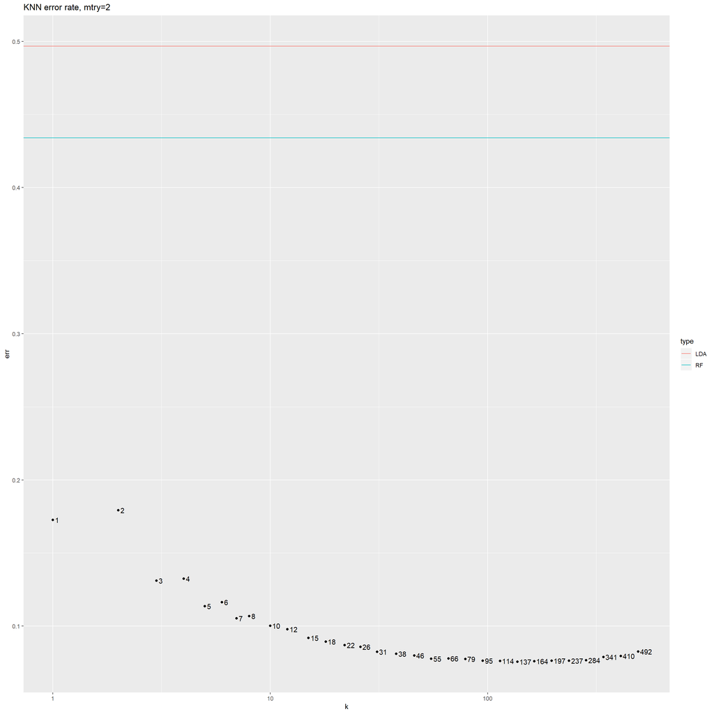

```r
#generate comparison error plots
compare.plot(dfTmp = knn4$prediction.table, lda.table = lda4$prediction.table,
             rf.table = rfm2$prediction.table, title.add = "mtry=2")
```

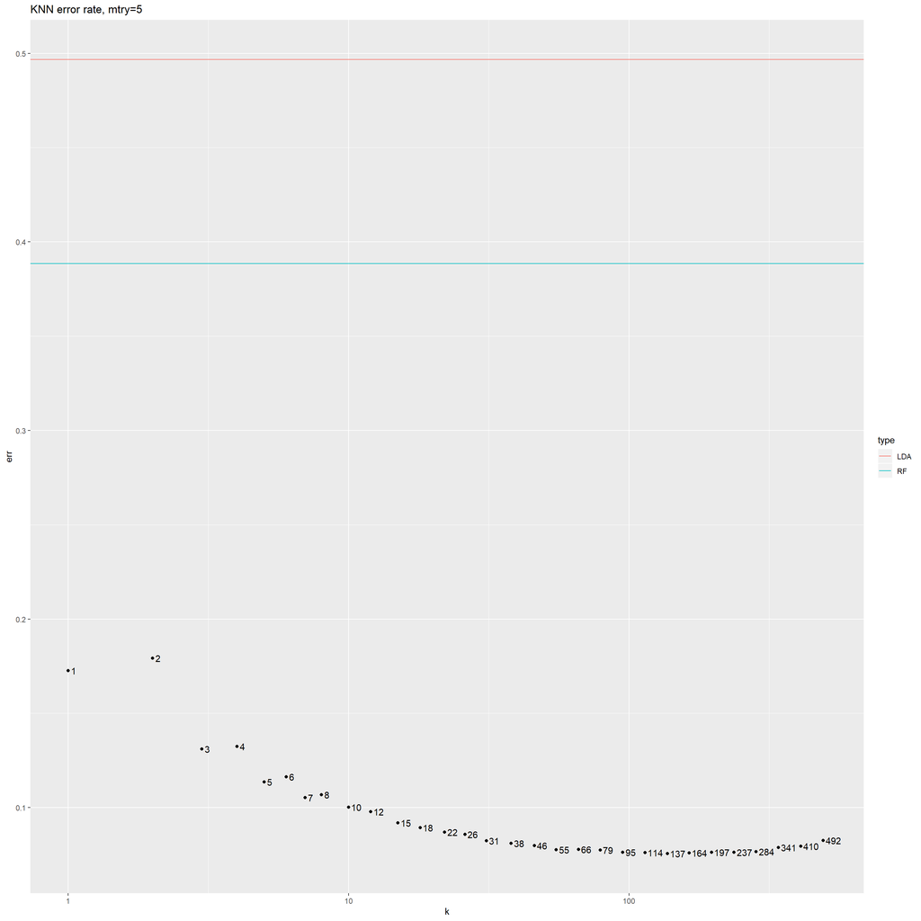

```r
compare.plot(dfTmp = knn4$prediction.table, lda.table = lda4$prediction.table,
             rf.table = rfm5$prediction.table, title.add = "mtry=5")
```

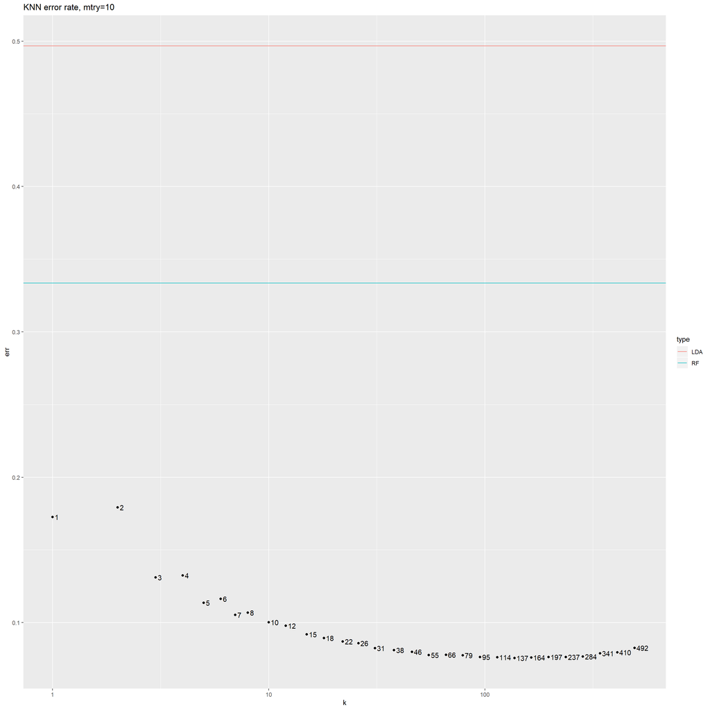

```r
compare.plot(dfTmp = knn4$prediction.table, lda.table = lda4$prediction.table,
             rf.table = rfm10$prediction.table, title.add = "mtry=10")
```

At a very high value of nObs, the LDA model is totally ineffective with an error rate equal to random chance.

The random forest shows significant improvment over increasing values of mtry. The error rate decreases over 10% between mtry=2 and mtry=10. This highlights an important hyperparameter for random forest models.

Most of the KNN models are significantly better than even the random forest models. Although the model has a ties limitation with k>500 it is not necessary to go beyond that to know the true minimum error. Because we know from a previous problem that the power of the curve is one less than the number dependent variables, or 3-1=2, we know that there is only one minimum. That minimum is located at approximately k=137. It’s also worth noting that k=10 through k=492 all have fairly good error rates at 10% or less.